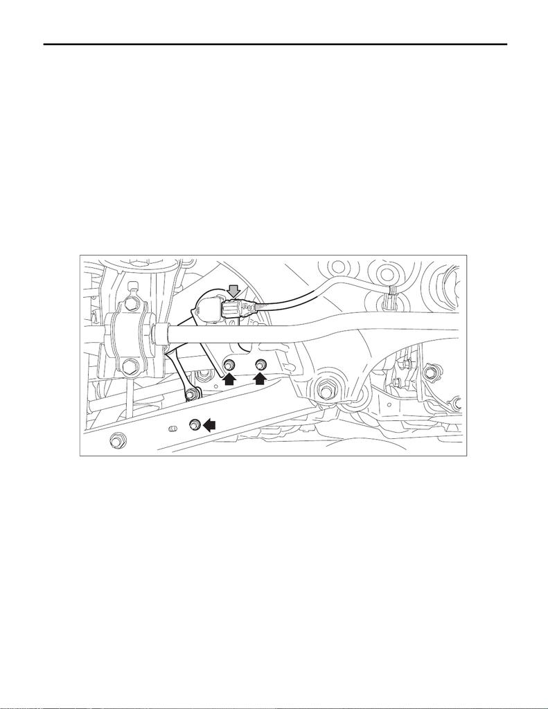

LI-74

Rear Height Sensor

LIGHTING SYSTEM

39.Rear Height Sensor

A: REMOVAL

CAUTION:

Always remove the sensor assembly - headlight beam leveler before removing any parts related to

the suspension. Do not apply impact to or forcibly move the sensor assembly - headlight beam lev-

eler. Doing so may cause sensor damage and malfunction.

1) Disconnect the ground cable from battery. <Ref. to NT-5, BATTERY, NOTE, Note.>

NOTE:

For models other than STI model, disconnect the ground terminal from battery sensor.

2) Lift up the vehicle.

3) Remove the rear wheel on the left side.

4) Remove the sensor assembly - headlight beam leveler.

CAUTION:

Do not disassemble the sensor and lever.

(1) Disconnect the connector.

(2) Remove the nuts, and remove the sensor assembly - headlight beam leveler.

B: INSTALLATION

1) Install the sensor assembly - headlight beam leveler.

Tightening torque:

7.5 N·m (0.8 kgf-m, 5.5 ft-lb)

2) Install the rear wheels.

Tightening torque:

120 N·m (12.2 kgf-m, 88.5 ft-lb)

3) Lower the vehicle.

4) Connect the battery ground terminal. <Ref. to NT-5, BATTERY, NOTE, Note.>

NOTE:

For models other than STI model, connect the ground terminal to battery sensor.

5) Perform reinitialization of the auto headlight beam leveler system. <Ref. to LI-17, REINITIALIZATION,

PROCEDURE, Auto Headlight Beam Leveler System.>

NOTE:

When replacing the rear vehicle height sensor with a new part, perform the initialization. <Ref. to LI-16, INI-

TIALIZATION, PROCEDURE, Auto Headlight Beam Leveler System.>

RS-00417

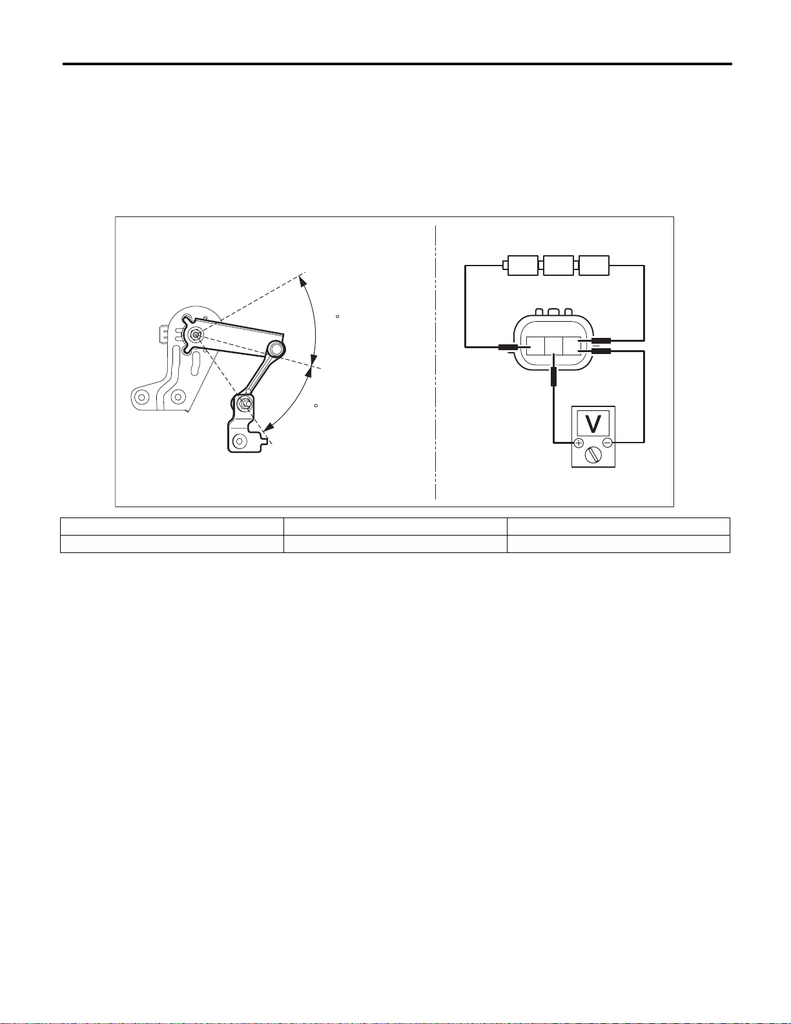

LI-75

Rear Height Sensor

LIGHTING SYSTEM

C: INSPECTION

Preparation tool:

Circuit tester

1) Connect three dry cell batteries (1.5 V) in series.

2) Connect the (+) side of the battery to terminal No. 3 of the sensor, and the (–) side of the battery to terminal

No. 1, and apply a voltage of 4.5 V between terminals No. 3 — No. 1.

3) With voltage applied, measure the voltage between connector terminals when the sensor link is moved

slowly up and down.

4) Replace the sensor assembly - headlight beam leveler if the inspection result is not within the standard

value.

Terminal No. Inspection conditions Standard

2 (+) — 1 (–) Move the link within the operation range. 0.5 — 4.1 V

+40

31

2

LI-01283

-45

(LOW)

(HIGH)

Reference point

for sensor output

(2.5V)